# Project: Investigate a Dataset (No-Show Appointments)

## 1. Introduction

The dataset contains information about medical checkup appointments. It has many features like date and time of appointment, Patient information like there ID, age, gender, enrollment in welfare scheme and health condition. It also contains information about the neighbourhood of hospital where appointment is fixed. Lastly information about whether patient showed up for appointment or not. We assess the dataset to find out which factor have affect on patients showing up for appointments or not.

```python
import numpy as np
import pandas as pd
import matplotlib.pyplot as plt
import seaborn as sb

%matplotlib inline
```

## 2. Data Wrangling

```python
df = pd.read_csv('noshowappointments.csv')
df.head(10)
```

|  | PatientId | AppointmentID | Gender | ScheduledDay | AppointmentDay | Age | Neighbourhood | Scholarship | Hipertension | Diabetes | Alcoholism | Handcap | SMS_received | No-show |
| --- | --- | --- | --- | --- | --- | --- | --- | --- | --- | --- | --- | --- | --- | --- |
| 0 | 2.987250e+13 | 5642903 | F | 2016-04-29T18:38:08Z | 2016-04-29T00:00:00Z | 62 | JARDIM DA PENHA | 0 | 1 | 0 | 0 | 0 | 0 | No |
| 1 | 5.589978e+14 | 5642503 | M | 2016-04-29T16:08:27Z | 2016-04-29T00:00:00Z | 56 | JARDIM DA PENHA | 0 | 0 | 0 | 0 | 0 | 0 | No |
| 2 | 4.262962e+12 | 5642549 | F | 2016-04-29T16:19:04Z | 2016-04-29T00:00:00Z | 62 | MATA DA PRAIA | 0 | 0 | 0 | 0 | 0 | 0 | No |
| 3 | 8.679512e+11 | 5642828 | F | 2016-04-29T17:29:31Z | 2016-04-29T00:00:00Z | 8 | PONTAL DE CAMBURI | 0 | 0 | 0 | 0 | 0 | 0 | No |
| 4 | 8.841186e+12 | 5642494 | F | 2016-04-29T16:07:23Z | 2016-04-29T00:00:00Z | 56 | JARDIM DA PENHA | 0 | 1 | 1 | 0 | 0 | 0 | No |
| 5 | 9.598513e+13 | 5626772 | F | 2016-04-27T08:36:51Z | 2016-04-29T00:00:00Z | 76 | REPÚBLICA | 0 | 1 | 0 | 0 | 0 | 0 | No |
| 6 | 7.336882e+14 | 5630279 | F | 2016-04-27T15:05:12Z | 2016-04-29T00:00:00Z | 23 | GOIABEIRAS | 0 | 0 | 0 | 0 | 0 | 0 | Yes |
| 7 | 3.449833e+12 | 5630575 | F | 2016-04-27T15:39:58Z | 2016-04-29T00:00:00Z | 39 | GOIABEIRAS | 0 | 0 | 0 | 0 | 0 | 0 | Yes |
| 8 | 5.639473e+13 | 5638447 | F | 2016-04-29T08:02:16Z | 2016-04-29T00:00:00Z | 21 | ANDORINHAS | 0 | 0 | 0 | 0 | 0 | 0 | No |
| 9 | 7.812456e+13 | 5629123 | F | 2016-04-27T12:48:25Z | 2016-04-29T00:00:00Z | 19 | CONQUISTA | 0 | 0 | 0 | 0 | 0 | 0 | No |

```python
df.shape
```

```
(110527, 14)
```

```python
df.info()
```

```
<class 'pandas.core.frame.DataFrame'>
RangeIndex: 110527 entries, 0 to 110526
Data columns (total 14 columns):
 #   Column          Non-Null Count   Dtype
---  ------          --------------   -----
 0   PatientId       110527 non-null  float64
 1   AppointmentID   110527 non-null  int64
 2   Gender          110527 non-null  object
 3   ScheduledDay    110527 non-null  object
 4   AppointmentDay  110527 non-null  object
 5   Age             110527 non-null  int64
 6   Neighbourhood   110527 non-null  object
 7   Scholarship     110527 non-null  int64
 8   Hipertension    110527 non-null  int64
 9   Diabetes        110527 non-null  int64
 10  Alcoholism      110527 non-null  int64
 11  Handcap         110527 non-null  int64
 12  SMS_received    110527 non-null  int64
 13  No-show         110527 non-null  object
dtypes: float64(1), int64(8), object(5)
memory usage: 11.8+ MB
```

```python
# checking for duplicate values
df.duplicated().sum()
```

```
0
```

No duplicates found.

```python
# checking for NaN values
df.isna().sum()
```

```
PatientId         0
AppointmentID     0
Gender            0
ScheduledDay      0
AppointmentDay    0
Age               0
Neighbourhood     0
Scholarship       0
Hipertension      0
Diabetes          0
Alcoholism        0
Handcap           0
SMS_received      0
No-show           0
dtype: int64
```

no missing values found.

```python
# checking for null values
df.isnull().sum()
```

```
PatientId         0
AppointmentID     0
Gender            0
ScheduledDay      0
AppointmentDay    0
Age               0
Neighbourhood     0
Scholarship       0
Hipertension      0
Diabetes          0
Alcoholism        0
Handcap           0
SMS_received      0
No-show           0
dtype: int64
```

no null values found.

## 3. Data Cleaning

```python
# changing column labels
col_name = ['patient_id', 'appointment_id', 'gender', 'schedule_day', 'appointment_day', 'age', 'neighbourhood',
         'scholarship', 'hypertension', 'diabetes', 'alcoholism', 'handicap', 'sms_received', 'no_show']
df.columns = col_name
df.info()
```

```
<class 'pandas.core.frame.DataFrame'>
RangeIndex: 110527 entries, 0 to 110526
Data columns (total 14 columns):
 #   Column           Non-Null Count   Dtype
---  ------           --------------   -----
 0   patient_id       110527 non-null  float64
 1   appointment_id   110527 non-null  int64
 2   gender           110527 non-null  object
 3   schedule_day     110527 non-null  object
 4   appointment_day  110527 non-null  object
 5   age              110527 non-null  int64
 6   neighbourhood    110527 non-null  object
 7   scholarship      110527 non-null  int64
 8   hypertension     110527 non-null  int64
 9   diabetes         110527 non-null  int64
 10  alcoholism       110527 non-null  int64
 11  handicap         110527 non-null  int64
 12  sms_received     110527 non-null  int64
 13  no_show          110527 non-null  object
dtypes: float64(1), int64(8), object(5)
memory usage: 11.8+ MB
```

```python
# change datatype of patient_id to int
df['patient_id'] = df['patient_id'].astype(int)
df.head()
```

|  | patient_id | appointment_id | gender | schedule_day | appointment_day | age | neighbourhood | scholarship | hypertension | diabetes | alcoholism | handicap | sms_received | no_show |
| --- | --- | --- | --- | --- | --- | --- | --- | --- | --- | --- | --- | --- | --- | --- |
| 0 | 29872499824296 | 5642903 | F | 2016-04-29T18:38:08Z | 2016-04-29T00:00:00Z | 62 | JARDIM DA PENHA | 0 | 1 | 0 | 0 | 0 | 0 | No |
| 1 | 558997776694438 | 5642503 | M | 2016-04-29T16:08:27Z | 2016-04-29T00:00:00Z | 56 | JARDIM DA PENHA | 0 | 0 | 0 | 0 | 0 | 0 | No |
| 2 | 4262962299951 | 5642549 | F | 2016-04-29T16:19:04Z | 2016-04-29T00:00:00Z | 62 | MATA DA PRAIA | 0 | 0 | 0 | 0 | 0 | 0 | No |
| 3 | 867951213174 | 5642828 | F | 2016-04-29T17:29:31Z | 2016-04-29T00:00:00Z | 8 | PONTAL DE CAMBURI | 0 | 0 | 0 | 0 | 0 | 0 | No |
| 4 | 8841186448183 | 5642494 | F | 2016-04-29T16:07:23Z | 2016-04-29T00:00:00Z | 56 | JARDIM DA PENHA | 0 | 1 | 1 | 0 | 0 | 0 | No |

```python
# convertong dates from string to datetime object
df['schedule_day'] = pd.to_datetime(df['schedule_day'])
df['appointment_day'] = pd.to_datetime(df['appointment_day'])
df.info()
```

```
<class 'pandas.core.frame.DataFrame'>
RangeIndex: 110527 entries, 0 to 110526
Data columns (total 14 columns):
 #   Column           Non-Null Count   Dtype
---  ------           --------------   -----
 0   patient_id       110527 non-null  int64
 1   appointment_id   110527 non-null  int64
 2   gender           110527 non-null  object
 3   schedule_day     110527 non-null  datetime64[ns, UTC]
 4   appointment_day  110527 non-null  datetime64[ns, UTC]
 5   age              110527 non-null  int64
 6   neighbourhood    110527 non-null  object
 7   scholarship      110527 non-null  int64
 8   hypertension     110527 non-null  int64
 9   diabetes         110527 non-null  int64
 10  alcoholism       110527 non-null  int64
 11  handicap         110527 non-null  int64
 12  sms_received     110527 non-null  int64
 13  no_show          110527 non-null  object
dtypes: datetime64[ns, UTC](2), int64(9), object(3)
memory usage: 11.8+ MB
```

```python
# adding new column for weekday of schedule day and appointmnet

# weekdays of schedule day
df['schedule_weekday'] = df['schedule_day'].dt.strftime('%A')
# weekdays of schedule day
df['appointment_weekday'] = df['appointment_day'].dt.strftime('%A')
df.info()
```

```
<class 'pandas.core.frame.DataFrame'>
RangeIndex: 110527 entries, 0 to 110526
Data columns (total 16 columns):
 #   Column               Non-Null Count   Dtype
---  ------               --------------   -----
 0   patient_id           110527 non-null  int64
 1   appointment_id       110527 non-null  int64
 2   gender               110527 non-null  object
 3   schedule_day         110527 non-null  datetime64[ns, UTC]
 4   appointment_day      110527 non-null  datetime64[ns, UTC]
 5   age                  110527 non-null  int64
 6   neighbourhood        110527 non-null  object
 7   scholarship          110527 non-null  int64
 8   hypertension         110527 non-null  int64
 9   diabetes             110527 non-null  int64
 10  alcoholism           110527 non-null  int64
 11  handicap             110527 non-null  int64
 12  sms_received         110527 non-null  int64
 13  no_show              110527 non-null  object
 14  schedule_weekday     110527 non-null  object
 15  appointment_weekday  110527 non-null  object
dtypes: datetime64[ns, UTC](2), int64(9), object(5)
memory usage: 13.5+ MB
```

```python
# converting no_show from string to integer for later analysis(like plotting)
df['no_show'] = df['no_show'].apply(lambda x: 0 if (x == 'No' or x == 'no') else 1)
```

```python
df.describe()
```

|  | patient_id | appointment_id | age | scholarship | hypertension | diabetes | alcoholism | handicap | sms_received | no_show |
| --- | --- | --- | --- | --- | --- | --- | --- | --- | --- | --- |
| count | 1.105270e+05 | 1.105270e+05 | 110527.000000 | 110527.000000 | 110527.000000 | 110527.000000 | 110527.000000 | 110527.000000 | 110527.000000 | 110527.000000 |
| mean | 1.474963e+14 | 5.675305e+06 | 37.088874 | 0.098266 | 0.197246 | 0.071865 | 0.030400 | 0.022248 | 0.321026 | 0.201933 |
| std | 2.560949e+14 | 7.129575e+04 | 23.110205 | 0.297675 | 0.397921 | 0.258265 | 0.171686 | 0.161543 | 0.466873 | 0.401444 |
| min | 3.921700e+04 | 5.030230e+06 | -1.000000 | 0.000000 | 0.000000 | 0.000000 | 0.000000 | 0.000000 | 0.000000 | 0.000000 |
| 25% | 4.172614e+12 | 5.640286e+06 | 18.000000 | 0.000000 | 0.000000 | 0.000000 | 0.000000 | 0.000000 | 0.000000 | 0.000000 |
| 50% | 3.173184e+13 | 5.680573e+06 | 37.000000 | 0.000000 | 0.000000 | 0.000000 | 0.000000 | 0.000000 | 0.000000 | 0.000000 |
| 75% | 9.439172e+13 | 5.725524e+06 | 55.000000 | 0.000000 | 0.000000 | 0.000000 | 0.000000 | 0.000000 | 1.000000 | 0.000000 |
| max | 9.999816e+14 | 5.790484e+06 | 115.000000 | 1.000000 | 1.000000 | 1.000000 | 1.000000 | 4.000000 | 1.000000 | 1.000000 |

```python
df.query("handicap > 1")
```

|  | patient_id | appointment_id | gender | schedule_day | appointment_day | age | neighbourhood | scholarship | hypertension | diabetes | alcoholism | handicap | sms_received | no_show | schedule_weekday | appointment_weekday |
| --- | --- | --- | --- | --- | --- | --- | --- | --- | --- | --- | --- | --- | --- | --- | --- | --- |
| 946 | 72825819926211 | 5582483 | M | 2016-04-14 09:26:08+00:00 | 2016-04-29 00:00:00+00:00 | 94 | BELA VISTA | 0 | 1 | 1 | 0 | 2 | 1 | 0 | Thursday | Friday |
| 1665 | 12429193284112 | 5525497 | M | 2016-03-30 09:16:41+00:00 | 2016-04-29 00:00:00+00:00 | 64 | SANTA MARTHA | 0 | 1 | 0 | 1 | 2 | 1 | 0 | Wednesday | Friday |
| 1666 | 12429193284112 | 5525498 | M | 2016-03-30 09:16:41+00:00 | 2016-04-29 00:00:00+00:00 | 64 | SANTA MARTHA | 0 | 1 | 0 | 1 | 2 | 0 | 0 | Wednesday | Friday |
| 2071 | 12429193284112 | 5640120 | M | 2016-04-29 10:08:48+00:00 | 2016-04-29 00:00:00+00:00 | 64 | SANTA MARTHA | 0 | 1 | 0 | 1 | 2 | 0 | 0 | Friday | Friday |
| 2091 | 14918292313383 | 5638626 | F | 2016-04-29 08:13:59+00:00 | 2016-04-29 00:00:00+00:00 | 11 | ANDORINHAS | 0 | 0 | 0 | 0 | 2 | 0 | 0 | Friday | Friday |
| ... | ... | ... | ... | ... | ... | ... | ... | ... | ... | ... | ... | ... | ... | ... | ... | ... |
| 108376 | 238721151823643 | 5756931 | F | 2016-06-01 08:48:28+00:00 | 2016-06-07 00:00:00+00:00 | 44 | ROMÃO | 0 | 1 | 1 | 0 | 2 | 1 | 0 | Wednesday | Tuesday |
| 109484 | 358949459162675 | 5752442 | M | 2016-05-31 11:45:57+00:00 | 2016-06-02 00:00:00+00:00 | 64 | DA PENHA | 0 | 1 | 1 | 0 | 2 | 0 | 0 | Tuesday | Thursday |
| 109733 | 566297621534644 | 5772744 | F | 2016-06-03 16:11:00+00:00 | 2016-06-07 00:00:00+00:00 | 34 | JUCUTUQUARA | 0 | 0 | 0 | 0 | 2 | 1 | 0 | Friday | Tuesday |
| 109975 | 45221851115953 | 5766970 | M | 2016-06-02 16:07:36+00:00 | 2016-06-06 00:00:00+00:00 | 39 | PRAIA DO SUÁ | 1 | 0 | 0 | 0 | 2 | 1 | 0 | Thursday | Monday |
| 110107 | 714371352369943 | 5761625 | F | 2016-06-02 06:44:00+00:00 | 2016-06-06 00:00:00+00:00 | 44 | RESISTÊNCIA | 0 | 0 | 0 | 0 | 2 | 1 | 0 | Thursday | Monday |

199 rows × 16 columns

```python
df.query("age < 0")
```

|  | patient_id | appointment_id | gender | schedule_day | appointment_day | age | neighbourhood | scholarship | hypertension | diabetes | alcoholism | handicap | sms_received | no_show | schedule_weekday | appointment_weekday |
| --- | --- | --- | --- | --- | --- | --- | --- | --- | --- | --- | --- | --- | --- | --- | --- | --- |
| 99832 | 465943158731293 | 5775010 | F | 2016-06-06 08:58:13+00:00 | 2016-06-06 00:00:00+00:00 | -1 | ROMÃO | 0 | 0 | 0 | 0 | 0 | 0 | 0 | Monday | Monday |

Only problem i can see is that **minimum age** is **-1** which is not possible and **handicap** values **greater than 1**. Maybe these are to show at what level a person is differently abled. Hence, I'll remove all rows with negitive ages and convert all handicap values greater than 1 to 1 as we are only interested at this point of time on whether a person is handicap or not.

```python
# converting all handicap values to 0 and 1
df['handicap'] = df['handicap'].apply(lambda x: 0 if x == 0 else 1)
```

```python
# removing all negative age values
df = df.query("age >= 0")
```

```python
df.describe()
```

|  | patient_id | appointment_id | age | scholarship | hypertension | diabetes | alcoholism | handicap | sms_received | no_show |
| --- | --- | --- | --- | --- | --- | --- | --- | --- | --- | --- |
| count | 1.105260e+05 | 1.105260e+05 | 110526.000000 | 110526.000000 | 110526.000000 | 110526.000000 | 110526.000000 | 110526.000000 | 110526.000000 | 110526.000000 |
| mean | 1.474934e+14 | 5.675304e+06 | 37.089219 | 0.098266 | 0.197248 | 0.071865 | 0.030400 | 0.020276 | 0.321029 | 0.201934 |
| std | 2.560943e+14 | 7.129544e+04 | 23.110026 | 0.297676 | 0.397923 | 0.258266 | 0.171686 | 0.140943 | 0.466874 | 0.401445 |
| min | 3.921700e+04 | 5.030230e+06 | 0.000000 | 0.000000 | 0.000000 | 0.000000 | 0.000000 | 0.000000 | 0.000000 | 0.000000 |
| 25% | 4.172536e+12 | 5.640285e+06 | 18.000000 | 0.000000 | 0.000000 | 0.000000 | 0.000000 | 0.000000 | 0.000000 | 0.000000 |
| 50% | 3.173184e+13 | 5.680572e+06 | 37.000000 | 0.000000 | 0.000000 | 0.000000 | 0.000000 | 0.000000 | 0.000000 | 0.000000 |
| 75% | 9.438963e+13 | 5.725523e+06 | 55.000000 | 0.000000 | 0.000000 | 0.000000 | 0.000000 | 0.000000 | 1.000000 | 0.000000 |
| max | 9.999816e+14 | 5.790484e+06 | 115.000000 | 1.000000 | 1.000000 | 1.000000 | 1.000000 | 1.000000 | 1.000000 | 1.000000 |

```python
# set scholarship and sms as categorical variable

df['scholarship'] = pd.Categorical(df['scholarship'], categories = list(df['scholarship'].unique()), ordered = True)

df['sms_received'] = pd.Categorical(df['sms_received'], categories = list(df['sms_received'].unique()), ordered=True)
```

```python
df.head()
```

|  | patient_id | appointment_id | gender | schedule_day | appointment_day | age | neighbourhood | scholarship | hypertension | diabetes | alcoholism | handicap | sms_received | no_show | schedule_weekday | appointment_weekday |
| --- | --- | --- | --- | --- | --- | --- | --- | --- | --- | --- | --- | --- | --- | --- | --- | --- |
| 0 | 29872499824296 | 5642903 | F | 2016-04-29 18:38:08+00:00 | 2016-04-29 00:00:00+00:00 | 62 | JARDIM DA PENHA | 0 | 1 | 0 | 0 | 0 | 0 | 0 | Friday | Friday |
| 1 | 558997776694438 | 5642503 | M | 2016-04-29 16:08:27+00:00 | 2016-04-29 00:00:00+00:00 | 56 | JARDIM DA PENHA | 0 | 0 | 0 | 0 | 0 | 0 | 0 | Friday | Friday |
| 2 | 4262962299951 | 5642549 | F | 2016-04-29 16:19:04+00:00 | 2016-04-29 00:00:00+00:00 | 62 | MATA DA PRAIA | 0 | 0 | 0 | 0 | 0 | 0 | 0 | Friday | Friday |
| 3 | 867951213174 | 5642828 | F | 2016-04-29 17:29:31+00:00 | 2016-04-29 00:00:00+00:00 | 8 | PONTAL DE CAMBURI | 0 | 0 | 0 | 0 | 0 | 0 | 0 | Friday | Friday |
| 4 | 8841186448183 | 5642494 | F | 2016-04-29 16:07:23+00:00 | 2016-04-29 00:00:00+00:00 | 56 | JARDIM DA PENHA | 0 | 1 | 1 | 0 | 0 | 0 | 0 | Friday | Friday |

```python
df.info()
```

```
<class 'pandas.core.frame.DataFrame'>
Int64Index: 110526 entries, 0 to 110526
Data columns (total 16 columns):
 #   Column               Non-Null Count   Dtype
---  ------               --------------   -----
 0   patient_id           110526 non-null  int64
 1   appointment_id       110526 non-null  int64
 2   gender               110526 non-null  object
 3   schedule_day         110526 non-null  datetime64[ns, UTC]
 4   appointment_day      110526 non-null  datetime64[ns, UTC]
 5   age                  110526 non-null  int64
 6   neighbourhood        110526 non-null  object
 7   scholarship          110526 non-null  category
 8   hypertension         110526 non-null  int64
 9   diabetes             110526 non-null  int64
 10  alcoholism           110526 non-null  int64
 11  handicap             110526 non-null  int64
 12  sms_received         110526 non-null  category
 13  no_show              110526 non-null  int64
 14  schedule_weekday     110526 non-null  object
 15  appointment_weekday  110526 non-null  object
dtypes: category(2), datetime64[ns, UTC](2), int64(8), object(4)
memory usage: 12.9+ MB
```

```python
# save to a new file for future use
df.to_csv('no_show_appointment_clean.csv', index = False)
```

## 4. Exploratory Data Analysis

**Question 1.** What is the proportion of people who show up for appointment v/s those who don't show up?

```
Proportion of appointments where patient didn't showed up:	0.2019
Proportion of appointments where patient showed up:		0.7981
```

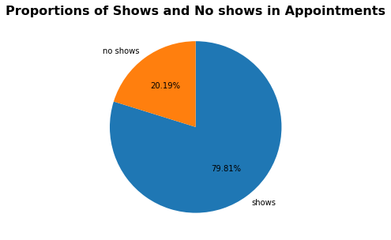

```python
# dataframe of all appointments where people showed up
df_show = df.query("no_show == 0")
# dataframe of all appointments where people didn't showed up
df_noshow = df.query("no_show == 1")
# calculating proportions
noshow_prop = df_noshow.shape[0] / df.shape[0]
show_prop = df_show.shape[0] / df.shape[0]
print('Proportion of appointments where patient didn\'t showed up:\t{:.4f}'.format(noshow_prop))
print('Proportion of appointments where patient showed up:\t\t{:.4f}\n'.format(show_prop))

# pie chart for same
plt.figure(figsize = [5,5])
ratios = [show_prop, noshow_prop]
labels = ['shows', 'no shows']
plt.pie(ratios, labels = labels, autopct = '%.2f%%', startangle = 90, counterclock = False);
plt.title('Proportions of Shows and No shows in Appointments', fontweight = 'semibold', fontsize = 16);
```

> **Observation:**
> - The number of times patients show up for appointment is greater than those who don't show up. Around 20.19% of appointments result in no show.

**Question 2.** Does Gender has any influence on patients showing up for appointment? What are the proportion of males and females showing up and not showing up for appointments?

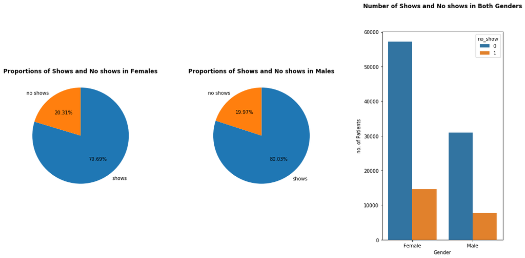

```python
# dataframe of all females
df_female = df.query("gender == 'F'")
# dataframe of all males
df_male = df.query("gender == 'M'")

# calculating proportions for females
noshow_prop = df_female.query("no_show == 1").shape[0] / df_female.shape[0]
show_prop = df_female.query("no_show == 0").shape[0] / df_female.shape[0]
ratio_female = [show_prop, noshow_prop]

# calculating proportions for males
noshow_prop = df_male.query("no_show == 1").shape[0] / df_male.shape[0]
show_prop = df_male.query("no_show == 0").shape[0] / df_male.shape[0]
ratio_male = [show_prop, noshow_prop]

plt.figure(figsize = [18, 8])

# plot pie chart for females
plt.subplot(1, 3, 1)
labels = ['shows', 'no shows']
plt.pie(ratio_female, labels = labels, autopct = '%.2f%%', startangle = 90, counterclock = False);
plt.title('Proportions of Shows and No shows in Females', fontweight = 'semibold', fontsize = 12);

# plot pie chart for males
plt.subplot(1, 3, 2)
labels = ['shows', 'no shows']
plt.pie(ratio_male, labels = labels, autopct = '%.2f%%', startangle = 90, counterclock = False);
plt.title('Proportions of Shows and No shows in Males', fontweight = 'semibold', fontsize = 12);

# plot barchart for both genders with total number of shows and no shows
plt.subplot(1, 3, 3)
g = sb.countplot(data = df, x = 'gender', hue = 'no_show');
plt.title('Number of Shows and No shows in Both Genders', fontweight = 'semibold', y = 1.1, fontsize = 12);
plt.xticks([0, 1], ['Female', 'Male']);
plt.xlabel('Gender');
plt.ylabel('no. of Patients');

plt.subplots_adjust(wspace = 0.5);
```

> **Observation:**
> - We can see that gender has almost no influence on whether a patient shows up for appoinment or not. In the last plot we can also see that number of female patients is greater than male patients.

**Question 3.** Whether receiving SMS Alerts for appointments have any affect on patients? Does it prompt them to show up for appointments?

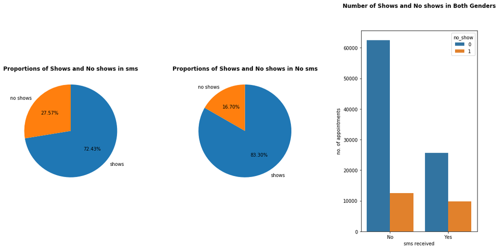

```python
# dataframe of  all patients receiving sms
df_sms = df.query("sms_received == 1")
# dataframe of all patients not receiving sms
df_nosms = df.query("sms_received == 0")

# calculating proportions for sms
noshow_prop = df_sms.query("no_show == 1").shape[0] / df_sms.shape[0]
show_prop = df_sms.query("no_show == 0").shape[0] / df_sms.shape[0]
ratio_sms = [show_prop, noshow_prop]

# calculating proportions for nosmss
noshow_prop = df_nosms.query("no_show == 1").shape[0] / df_nosms.shape[0]
show_prop = df_nosms.query("no_show == 0").shape[0] / df_nosms.shape[0]
ratio_nosms = [show_prop, noshow_prop]

plt.figure(figsize = [18, 8])

# plot pie chart for sms
plt.subplot(1, 3, 1)
labels = ['shows', 'no shows']
plt.pie(ratio_sms, labels = labels, autopct = '%.2f%%', startangle = 90, counterclock = False);
plt.title('Proportions of Shows and No shows in sms', fontweight = 'semibold', fontsize = 12);

# plot pie chart for nosms
plt.subplot(1, 3, 2)
labels = ['shows', 'no shows']
plt.pie(ratio_nosms, labels = labels, autopct = '%.2f%%', startangle = 90, counterclock = False);
plt.title('Proportions of Shows and No shows in No sms', fontweight = 'semibold', fontsize = 12);

# plot barchart for both cases of sms with total number of shows and no shows
plt.subplot(1, 3, 3)
g = sb.countplot(data = df, x = 'sms_received', hue = 'no_show');
plt.title('Number of Shows and No shows in Both Genders', fontweight = 'semibold', y = 1.1, fontsize = 12);
plt.xticks([0, 1], ['No', 'Yes']);
plt.xlabel('sms received');
plt.ylabel('no. of appointments');

plt.subplots_adjust(wspace = 0.5);
```

> **Observation:**
> - The proportion of patients who showed up but didn't receive SMS alerts is 83.3%, whereas the proportion of patients who showed and received SMS alerts is 72.43%.

**Question 4.** Does day of week on which appointment is fixed has any influence on patients showing up for appointment? What are the proportion of people not showing up for appointments on different days of week?

```python
saturday = df.query('appointment_weekday == "Saturday"').shape[0] / df.shape[0]
saturday * 100
```

```
0.035285815102328866
```

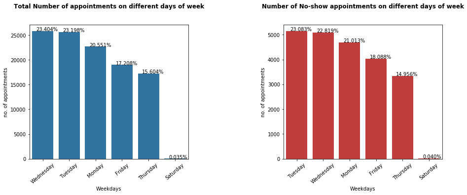

```python
def percent(plot, feature):
    total = len(feature)
    for p in ax.patches:
        percentage = '{:.3f}%'.format(100 * p.get_height()/total)
        x = p.get_x() + p.get_width() / 5
        y = p.get_y() + p.get_height() + 10
        ax.annotate(percentage, (x, y), size = 10)


base_color1 = sb.color_palette()[0]
base_color2 = sb.color_palette()[3]


plt.figure(figsize = [15, 5])

# plot for no of appointments on different days of week
plt.subplot(1, 2, 1)
cat_order2 = list(df['appointment_weekday'].value_counts().index)
ax = sb.countplot(data = df, x = 'appointment_weekday', order = cat_order2, color = base_color1);
percent(ax, df['appointment_weekday']);
plt.xticks(rotation = 40);
plt.title('Total Number of appointments on different days of week', y = 1.1, fontweight = 'semibold', fontsize = 12);
plt.xlabel('Weekdays');
plt.ylabel('no. of appointments');

# plot for no. of appointments resulting in no show up on different days of week
plt.subplot(1, 2, 2)
df_noshow = df.query("no_show == 1")
cat_order1 = list(df_noshow['appointment_weekday'].value_counts().index)
ax = sb.countplot(data = df_noshow, x = 'appointment_weekday', order = cat_order1, color = base_color2);
percent(ax, df_noshow['appointment_weekday']);
plt.xticks(rotation = 40);
plt.title('Number of No-show appointments on different days of week', y = 1.1, fontweight = 'semibold', fontsize = 12);
plt.xlabel('Weekdays');
plt.ylabel('no. of appointments');

plt.subplots_adjust(wspace = 0.6);
```

> **Observation:**
> - It can be clearly seen in first sub plot that number of appoinments on Saturday is very less. Also from second sublot we can infer that day of weekday has not much affect on patients showing up for appointments.

**Question 5.** We would like to investigate whether scholarship has any influence on patients showing up for appointment? What are the proportion of no show appointments depending on whether they have scholarship or not? *Scholarship in dataset indicates whether or not the patient is enrolled in welfare program.*

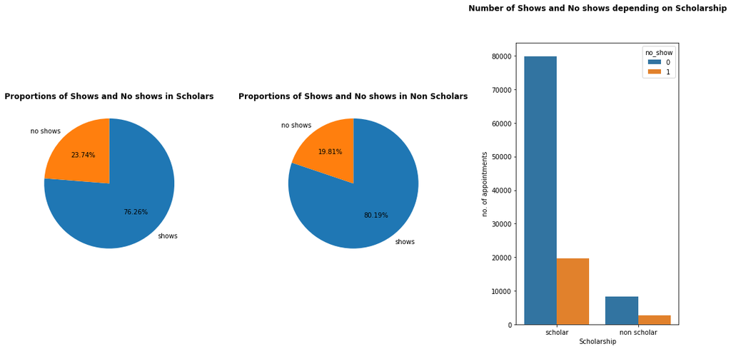

```python
# dataframe of all scholars
df_scholar = df.query("scholarship == 1")
# dataframe of all non scholars
df_no_scholar = df.query("scholarship == 0")

# calculating proportions for scholars
noshow_prop = df_scholar.query("no_show == 1").shape[0] / df_scholar.shape[0]
show_prop = df_scholar.query("no_show == 0").shape[0] / df_scholar.shape[0]
ratio_scholar = [show_prop, noshow_prop]

# calculating proportions for no_scholars
noshow_prop = df_no_scholar.query("no_show == 1").shape[0] / df_no_scholar.shape[0]
show_prop = df_no_scholar.query("no_show == 0").shape[0] / df_no_scholar.shape[0]
ratio_no_scholar = [show_prop, noshow_prop]

plt.figure(figsize = [18, 8])

# plot pie chart for scholars
plt.subplot(1, 3, 1)
labels = ['shows', 'no shows']
plt.pie(ratio_scholar, labels = labels, autopct = '%.2f%%', startangle = 90, counterclock = False);
plt.title('Proportions of Shows and No shows in Scholars', fontweight = 'semibold', fontsize = 12);

# plot pie chart for non scholars
plt.subplot(1, 3, 2)
labels = ['shows', 'no shows']
plt.pie(ratio_no_scholar, labels = labels, autopct = '%.2f%%', startangle = 90, counterclock = False);
plt.title('Proportions of Shows and No shows in Non Scholars', fontweight = 'semibold', fontsize = 12);

# plot barchart for both with total number of shows and no shows
plt.subplot(1, 3, 3)
g = sb.countplot(data = df, x = 'scholarship', hue = 'no_show');
plt.title('Number of Shows and No shows depending on Scholarship', fontweight = 'semibold', y = 1.1, fontsize = 12);
plt.xticks([0, 1], ['scholar', 'non scholar']);
plt.xlabel('Scholarship');
plt.ylabel('no. of appointments');

plt.subplots_adjust(wspace = 0.5);
```

**6.** Do people with certain health conditions don't show up for appointment more often?

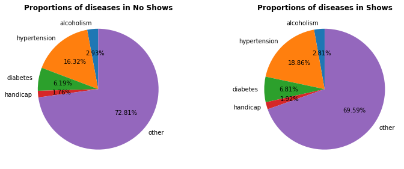

```python
# dataframe of all appointments where people showed up
df_show = df.query("no_show == 0")
# dataframe of all appointments where people didn't showed up
df_noshow = df.query("no_show == 1")

alch_show = df_show.query("alcoholism == 1").shape[0] / df_show.shape[0]
hypr_show = df_show.query("hypertension == 1").shape[0] / df_show.shape[0]
diab_show = df_show.query("diabetes == 1").shape[0] / df_show.shape[0]
hand_show = df_show.query("handicap == 1").shape[0] / df_show.shape[0]
other_show = df_show.query("handicap == 0 and alcoholism == 0 and hypertension == 0 and diabetes == 0").shape[0] / df_show.shape[0]
show_list = [alch_show, hypr_show, diab_show, hand_show, other_show]

alch_noshow = df_noshow.query("alcoholism == 1").shape[0] / df_noshow.shape[0]
hypr_noshow = df_noshow.query("hypertension == 1").shape[0] / df_noshow.shape[0]
diab_noshow = df_noshow.query("diabetes == 1").shape[0] / df_noshow.shape[0]
hand_noshow = df_noshow.query("handicap == 1").shape[0] / df_noshow.shape[0]
other_noshow = df_show.query("handicap == 0 and alcoholism == 0 and hypertension == 0 and diabetes == 0").shape[0] / df_show.shape[0]
noshow_list = [alch_noshow, hypr_noshow, diab_noshow, hand_noshow, other_noshow]


plt.figure(figsize = [18, 8])

# plot pie chart no show
plt.subplot(1, 3, 1)
labels = ['alcoholism', 'hypertension', 'diabetes', 'handicap', 'other']
plt.pie(noshow_list, labels = labels, autopct = '%.2f%%', startangle = 90, counterclock = True); #
plt.title('Proportions of diseases in No Shows', fontweight = 'semibold', fontsize = 12);

# plot pie chart for show
plt.subplot(1, 3, 2)
plt.pie(show_list, labels = labels, autopct = '%.2f%%', startangle = 90, counterclock = True);
plt.title('Proportions of diseases in Shows', fontweight = 'semibold', fontsize = 12);

plt.subplots_adjust(wspace = 0.5);
```

> **Observation:**
> - We can see that patients suffering from alcoholism show up a little less than patients sufferong from other diseases.

**7.** Do appointments in certain neighbourhood or locality have larger no show rates?

*Note*: as the number of neighbourhoods is large(around 81), I'll focus on 10 neighbourhoods with largest number of appointments.

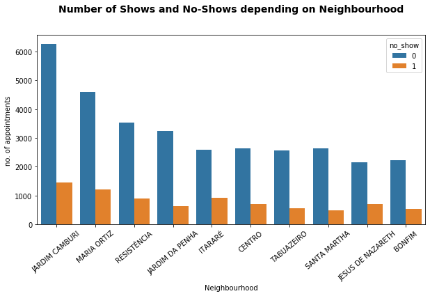

```python
top10_neigh = list(df['neighbourhood'].value_counts().index)[:10]

plt.figure(figsize = [10, 5])
df_neigh = df[df['neighbourhood'].isin(top10_neigh)]

ct_count = df_neigh.groupby(['neighbourhood', 'no_show']).size()
ct_count = ct_count.reset_index(name = 'count')
ct_count
ax = sb.barplot(data=ct_count, x = 'neighbourhood', y = 'count' , hue = 'no_show', order = top10_neigh);
plt.xticks(rotation = 40);
plt.xlabel('Neighbourhood')
plt.ylabel('no. of appointments');
plt.title('Number of Shows and No-Shows depending on Neighbourhood', y = 1.1, fontsize = 14, fontweight = 'semibold');
```

**Question 8.** Does patients in certain age bracket show up less or more for appointments?

```python
# to check for most common values for ride duration, so that outliers or extreme values are not plotted
df['age'].describe(percentiles = [0.99])
```

```
count    110526.000000
mean         37.089219
std          23.110026
min           0.000000
50%          37.000000
99%          86.000000
max         115.000000
Name: age, dtype: float64
```

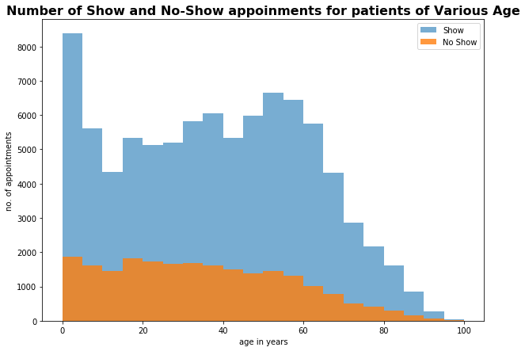

```python
plt.figure(figsize = [10, 7])

# dataframe of all appointments where people showed up
df_show = df.query("no_show == 0")
# dataframe of all appointments where people didn't showed up
df_noshow = df.query("no_show == 1")

bins = np.arange(0, 105, 5)
plt.hist(data = df_show, x = 'age', bins = bins, alpha = 0.6, label = 'Show');
plt.hist(data = df_noshow, x = 'age', bins = bins, alpha = 0.8, label = 'No Show');
plt.xlabel('age in years');
plt.ylabel('no. of appointments');
plt.title('Number of Show and No-Show appoinments for patients of Various Age', y = 1.0, fontweight = 'semibold', fontsize = 16);
plt.legend(loc = 'upper right');
```

## 6. Limitations

> - Column handicap had values greater than 1 which may have been used to show the degree to which a person is differently abled. I converted all these values to 1 for easier analysis. This may have resulted in alteration of data losing important informations and insights.
> - Age had negative values.
> - All the inferences and conclusions we maded apply only to the analyzed dataset. Statistical analysis was not carried out on the dataset to check whether sample is representative of the population.

**Resources**

- [Stack Overflow Post](https://stackoverflow.com/questions/35692781/python-plotting-percentage-in-seaborn-bar-plot)